# Homework-02

STAT 5732: Introduction to R for Data Science I

Author

Affiliation

Selin Kirbas

The Ohio State University

Published

March 21, 2025

## R4DS 17.3.4

### Exercise 2

#### Question

Compare `dep_time`, `sched_dep_time` and `dep_delay`. Are they consistent? Explain your findings.

#### Solution

```r
# Look at the first few rows to understand the data
flights %>%
  select(dep_time, sched_dep_time, dep_delay) %>%
  head(10)
```

```
# A tibble: 10 × 3
   dep_time sched_dep_time dep_delay
      <int>          <int>     <dbl>
 1      517            515         2
 2      533            529         4
 3      542            540         2
 4      544            545        -1
 5      554            600        -6
 6      554            558        -4
 7      555            600        -5
 8      557            600        -3
 9      557            600        -3
10      558            600        -2
```

```r
# Create a calculated delay to compare with the provided dep_delay
flights %>%
  mutate(
    # Convert times to minutes since midnight
    dep_time_mins = (dep_time %/% 100) * 60 + (dep_time %% 100),
    sched_dep_time_mins = (sched_dep_time %/% 100) * 60 + (sched_dep_time %% 100),
    # Calculate delay as difference between actual and scheduled
    calculated_delay = dep_time_mins - sched_dep_time_mins,
    # Handle overnight flights (negative delays)
    calculated_delay = ifelse(calculated_delay < -800, calculated_delay + 24*60, calculated_delay),
    # Check consistency
    is_consistent = dep_delay == calculated_delay
  ) %>%
  select(dep_time, sched_dep_time, dep_delay, calculated_delay, is_consistent) %>%
  filter(!is_consistent) %>%
  head(10)
```

```
# A tibble: 10 × 5
   dep_time sched_dep_time dep_delay calculated_delay is_consistent
      <int>          <int>     <dbl>            <dbl> <lgl>
 1      848           1835       853             -587 FALSE
 2      641            900      1301             -139 FALSE
 3     1121           1635      1126             -314 FALSE
 4      603           1645       798             -642 FALSE
 5      657           1930       687             -753 FALSE
 6      756           1700       896             -544 FALSE
 7      830           1845       825             -615 FALSE
 8      625           1925       660             -780 FALSE
 9      705           1700       845             -595 FALSE
10      734           1725       849             -591 FALSE
```

### Exercise 5

#### Question

On what day of the week should you leave if you want to minimise the chance of a delay?

#### Solution

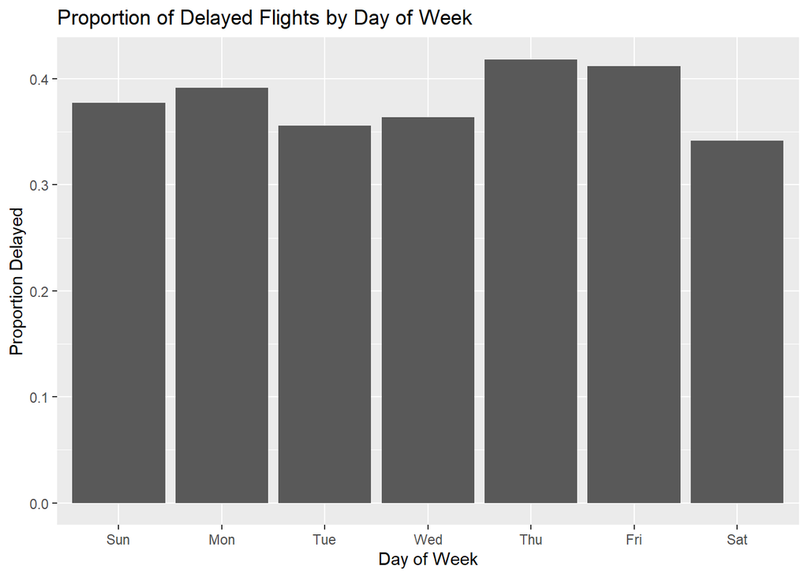

```r
# Use make_datetime_100 function to convert
make_datetime_100 <- function(year, month, day, time) {
  make_datetime(year, month, day, time %/% 100, time %% 100)
}

# Add datetime columns and extract weekday
flights_dt <- flights %>%
  mutate(
    dep_datetime = make_datetime_100(year, month, day, dep_time),
    sched_dep_datetime = make_datetime_100(year, month, day, sched_dep_time),
    weekday = wday(sched_dep_datetime, label = TRUE)
  )

# Calculate proportion of delayed flights by weekday
delay_by_weekday <- flights_dt %>%
  group_by(weekday) %>%
  summarise(
    total_flights = n(),
    delayed_flights = sum(dep_delay > 0, na.rm = TRUE),
    proportion_delayed = delayed_flights / total_flights
  ) %>%
  arrange(proportion_delayed)

# Plot results
ggplot(delay_by_weekday, aes(x = weekday, y = proportion_delayed)) +
  geom_col() +
  labs(title = "Proportion of Delayed Flights by Day of Week",
       x = "Day of Week",
       y = "Proportion Delayed")
```

```r
delay_by_weekday
```

```
# A tibble: 7 × 4
  weekday total_flights delayed_flights proportion_delayed
  <ord>           <int>           <int>              <dbl>
1 Sat             38720           13215              0.341
2 Tue             50422           17951              0.356
3 Wed             50060           18208              0.364
4 Sun             46357           17487              0.377
5 Mon             50690           19845              0.391
6 Fri             50308           20719              0.412
7 Thu             50219           21007              0.418
```

If you want to minimize the chance of experiencing a delay, you should schedule your flight on a Saturday since the analysis shows that Saturday has the lowest proportion of delayed flights.

### Exercise 6

#### Question

What makes the distribution of `diamonds$carat` and `flights$sched_dep_time` similar?

#### Solution

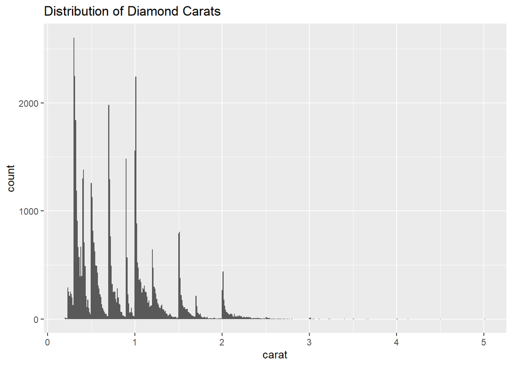

```r
# Look at distributions
p1 <- ggplot(diamonds, aes(x = carat)) +
  geom_histogram(binwidth = 0.01) +
  labs(title = "Distribution of Diamond Carats")

p2 <- ggplot(flights, aes(x = sched_dep_time)) +
  geom_histogram(binwidth = 10) +
  labs(title = "Distribution of Scheduled Departure Times")

p1
```

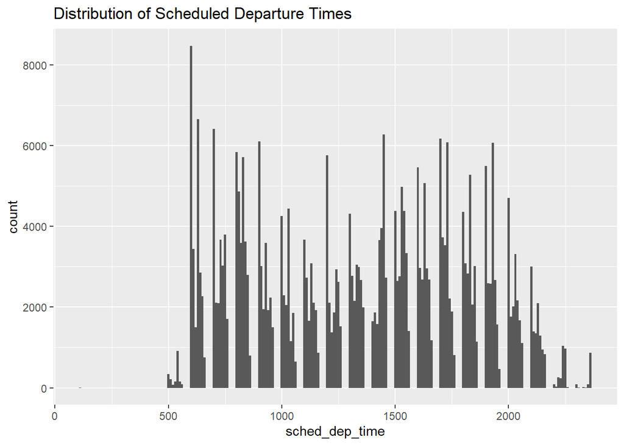

```r
p2
```

Both distributions show patterns with regular spikes at certain values. For `diamonds$carat`, there are spikes at common round numbers (0.5, 1.0, 1.5). This reflects human preference for round numbers when sizing diamonds.

`flights$sched_dep_time` shows spikes at round-hour times (900, 1000, 1100) and half-hour times (930, 1030, 1130). This reflects airline scheduling preferences to depart at “round” times that are easy for humans to remember and plan around.

Both distributions show how human preferences for round numbers affect these objective measurements, creating regular patterns in the data rather than smooth continuous distributions.

### Exercise 7

#### Question

Confirm our hypothesis that the early departures of flights in minutes 20-30 and 50-60 are caused by scheduled flights that leave early. Hint: create a binary variable that tells you whether or not a flight was delayed.

#### Solution

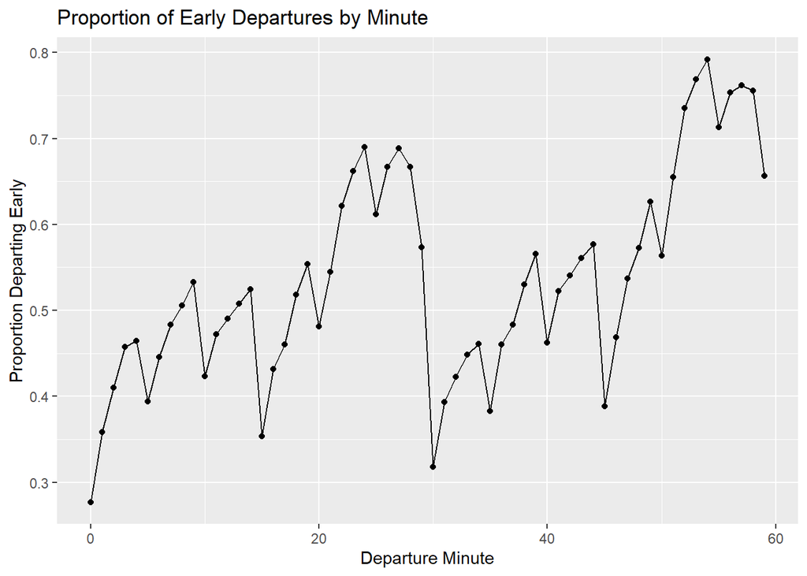

```r
# Get departure minute
flights_with_minutes <- flights %>%
  mutate(
    dep_minute = dep_time %% 100,
    sched_dep_minute = sched_dep_time %% 100,
    early = dep_delay < 0
  )

# Count early vs delayed flights by minute
departure_stats <- flights_with_minutes %>%
  filter(!is.na(dep_minute)) %>%
  group_by(dep_minute) %>%
  summarise(
    total = n(),
    early_departures = sum(early),
    prop_early = early_departures / total
  )

# Plot proportion of early departures by minute
ggplot(departure_stats, aes(x = dep_minute, y = prop_early)) +
  geom_line() +
  geom_point() +
  labs(title = "Proportion of Early Departures by Minute",
       x = "Departure Minute",
       y = "Proportion Departing Early")
```

```r
# Look at minutes 20-30 and 50-60
flights_with_minutes %>%
  filter(dep_minute >= 20 & dep_minute <= 30 |
         dep_minute >= 50 & dep_minute <= 59) %>%
  group_by(sched_dep_minute) %>%
  summarise(
    count = n(),
    early_count = sum(early),
    early_prop = early_count / count
  ) %>%
  arrange(sched_dep_minute)
```

```
# A tibble: 60 × 4
   sched_dep_minute count early_count early_prop
              <dbl> <int>       <int>      <dbl>
 1                0 40527       36508      0.901
 2                1  1114         886      0.795
 3                2   383         301      0.786
 4                3   580         411      0.709
 5                4   426         276      0.648
 6                5  4626        3178      0.687
 7                6   356         182      0.511
 8                7   235         112      0.477
 9                8   297         115      0.387
10                9   272          63      0.232
# ℹ 50 more rows
```

This confirms the hypothesis. Flights that depart in minutes 20-30 and 50-60 have a higher proportion of early departures.

## R4DS 17.4.4

### Exercise 1

#### Question

Explain `days(!overnight)` and `days(overnight)` to someone who has just started learning R. What is the key fact you need to know?

#### Solution

In R, logical values convert to numbers in calculations so TRUE becomes 1 and FALSE becomes 0. `days(overnight)` gives one day if overnight is TRUE and zero days if FALSE. `days(!overnight)` gives zero days if overnight is TRUE and one day if FALSE.

### Exercise 3

#### Question

Write a function that given your birthday (as a date), returns how old you are in years.

#### Solution

```r
# Using lubridate's time period functions
calculate_age_interval <- function(birthday) {
  today <- Sys.Date()
  # Create an interval from birthday to today
  age_interval <- interval(birthday, today)
  # Convert to years
  age_years <- age_interval / years(1)
  # Return the floor of the age in years
  return(floor(age_years))
}

my_birthday <- ymd("2002-06-04")
calculate_age_interval(my_birthday)
```

```
[1] 22
```

This function calculates age by creating a time interval between the birthday and today’s date, then converts this interval to years using lubridate’s time period functions, which makes sure we get completed years of age.